# Stroke Prediction

Dina, Jalen, Marcellus

2023-10-23

# Packages Needed

# Data Description

In this document, we will describe the results of the analysis for the Stroke Prediction dataset from the website [link]https://www.kaggle.com/datasets/fedesoriano/stroke-prediction-dataset/data. Kaggle is an online platform and community that focuses on data science, machine learning, and artificial intelligence by providing access to data, tools, and a platform for collaboration. The Stroke Prediction Dataset is used for research and analysis to understand the factors contributing to strokes and to build predictive models for identifying individuals at risk of experiencing a stroke. It includes qualitative variables like a person’s marital status, and quantitative variables like body mass index (BMI), for each individual (1). The data consists of 5,110 observations with 12 quantitative and qualitative variables. The 12 variables are the following:

1. ID: An anonymous identifier for each individual.
2. Gender: The gender of the individual (e.g., Male, Female, Other).
3. Age: The age of the individual.
4. Hypertension: Indicates whether the individual has hypertension.
5. Heart Disease: Indicates whether the individual has heart disease.
6. Marital Status: The marital status of the individual (e.g., Married or Single).
7. Work Type: The type of work the individual is engaged in.
8. Residence Type: Whether the individual lives in an urban or rural area.
9. Average Glucose Level: The average glucose level of the individual.
10. BMI (Body Mass Index): The Body Mass Index of the individual.
11. Smoking Status: The smoking status of the individual (e.g., Smoker, Non-smoker, etc.).
12. Stroke: The binary response variable, indicating whether the individual had a stroke (0 = No, 1 = Yes).

# Importing and Cleaning the Data

ID has been removed for analysis purposes. Most of the qualitative variables were re-coded to be binary. Given the large sample size of the data, missing values were removed. We also changed the categorical data to be factors and not numeric since most are binary. None of the categorical variables have high levels for further evaluation. The observation for gender = Other, was removed for this data.

```
## 'data.frame':    4908 obs. of  11 variables:
##  $ gender           : Factor w/ 2 levels "Female","Male": 2 2 1 1 2 2 1 1 1 1 ...
##  $ age              : num  67 80 49 79 81 74 69 78 81 61 ...
##  $ hypertension     : Factor w/ 2 levels "0","1": 1 1 1 2 1 2 1 1 2 1 ...
##  $ heart_disease    : Factor w/ 2 levels "0","1": 2 2 1 1 1 2 1 1 1 2 ...
##  $ ever_married     : Factor w/ 2 levels "No","Yes": 2 2 2 2 2 2 1 2 2 2 ...
##  $ work_type        : Factor w/ 5 levels "children","Govt_job",..: 4 4 4 5 4 4 4 4 4 2 ...
##  $ Residence_type   : Factor w/ 2 levels "Rural","Urban": 2 1 2 1 2 1 2 2 1 1 ...
##  $ avg_glucose_level: num  229 106 171 174 186 ...
##  $ bmi              : num  36.6 32.5 34.4 24 29 27.4 22.8 24.2 29.7 36.8 ...
##  $ smoking_status   : Factor w/ 4 levels "formerly smoked",..: 1 2 3 2 1 2 2 4 2 3 ...
##  $ stroke           : Factor w/ 2 levels "0","1": 2 2 2 2 2 2 2 2 2 2 ...
```

# Analyzing the Dataset

### Correlation of Numeric Explanatory Variables, Distribution of Response Variable, and Outliers in the Dataset

```
##                         age avg_glucose_level       bmi
## age               1.0000000         0.2359996 0.3333142
## avg_glucose_level 0.2359996         1.0000000 0.1756717
## bmi               0.3333142         0.1756717 1.0000000
```

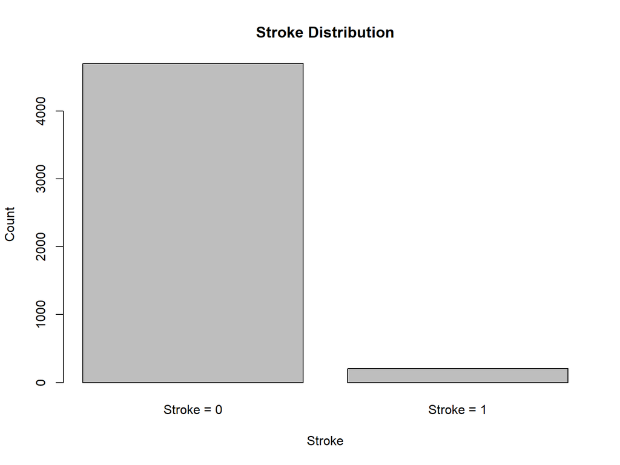

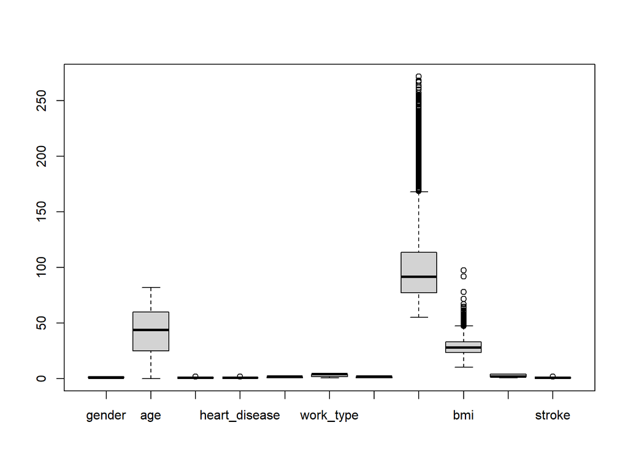

We can see that none of the numeric explanatory variables are highly correlated with each other. However, there is a high imbalance between stroke patients and non-stroke patients.We can also see many outliers in the average glucose level and BMI.

### Histogram of BMI

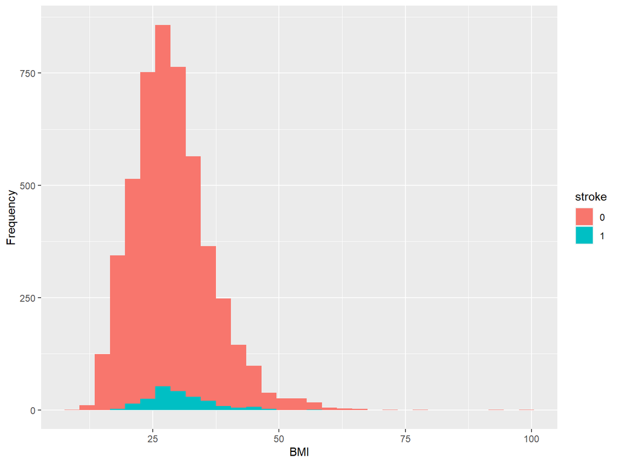

BMI by stroke status

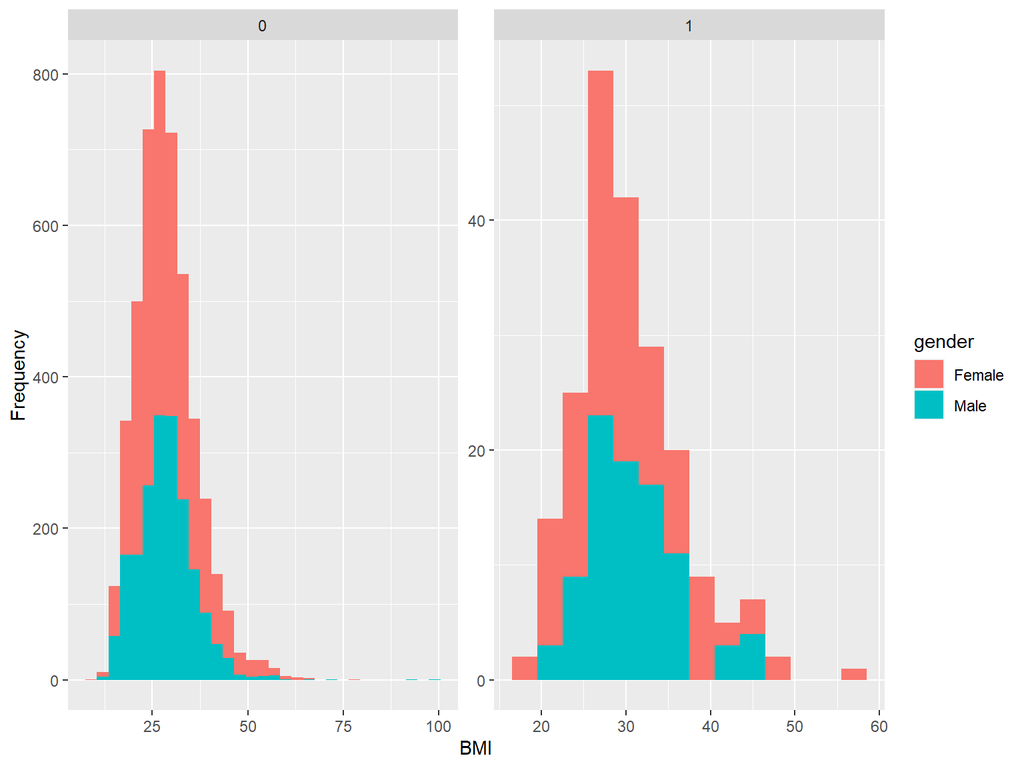

Here is a histogram of BMI by stroke status overlapped by gender. There does not seem to be a relationship between BMI and stroke status for males and females.

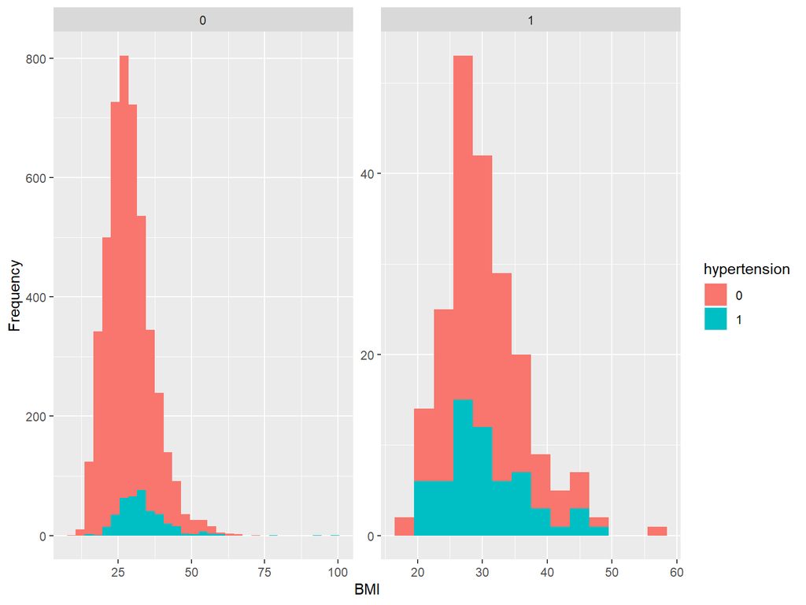

Histogram of BMI by stroke status overlapped by hypertension. There doesn’t look to be an obvious relationship between BMI and stroke for people that have hypertension and don’t.

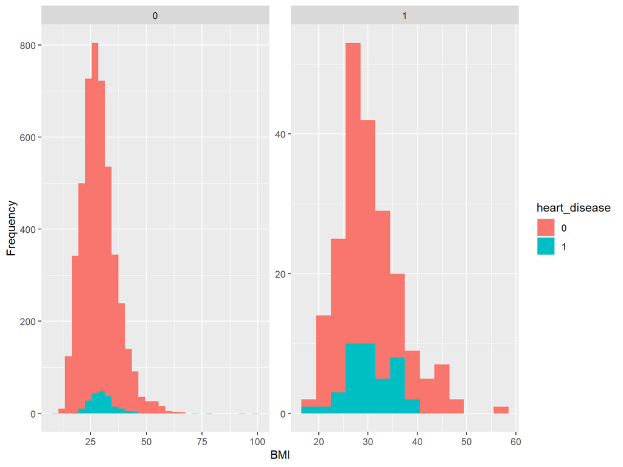

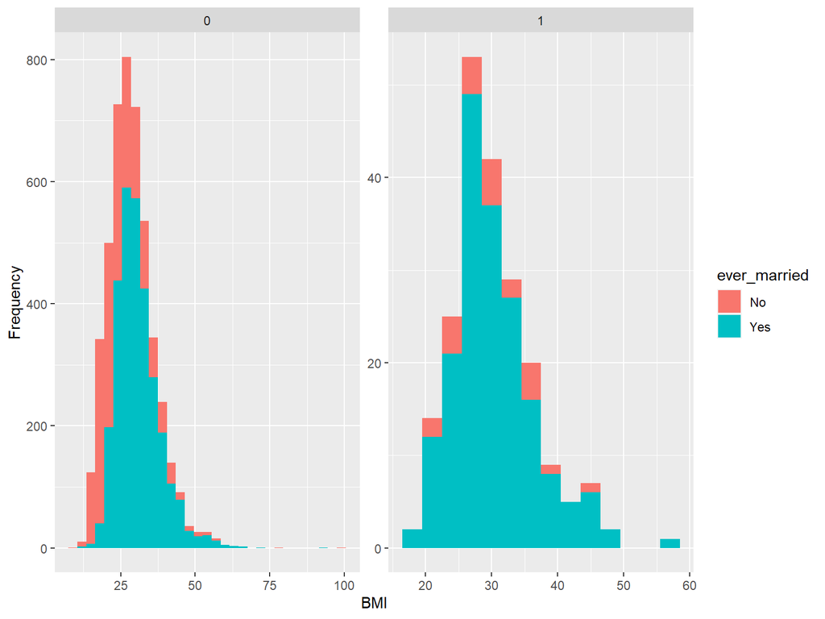

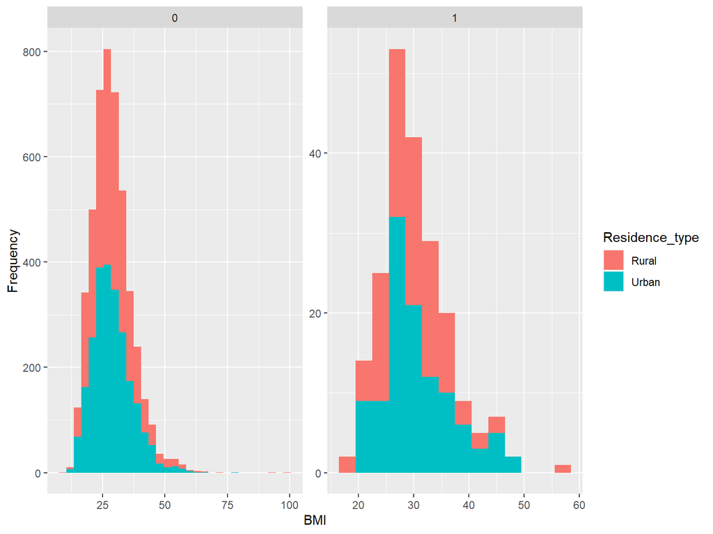

Histogram of BMI by stroke status overlapped by Residence type. There doesn’t seem to be much of a difference between the two.

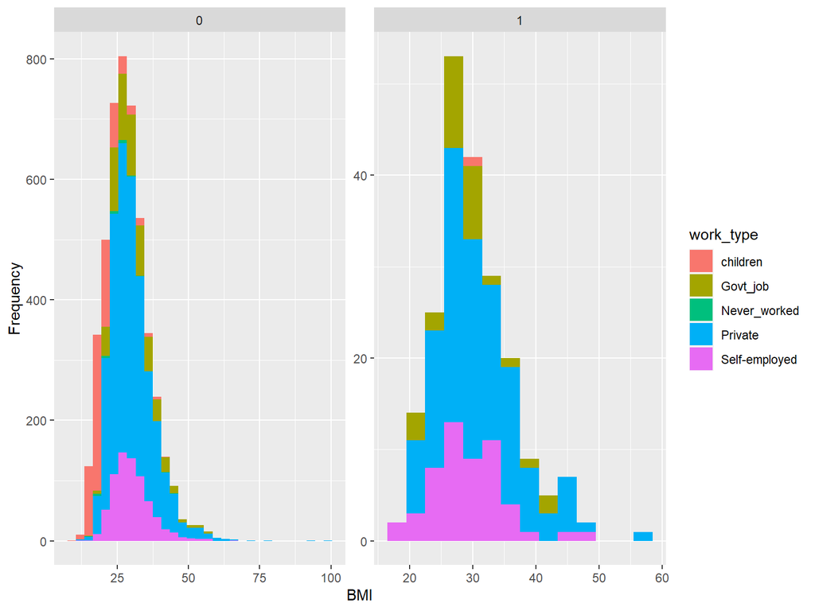

Histogram of BMI by stroke status overlapped by work type.

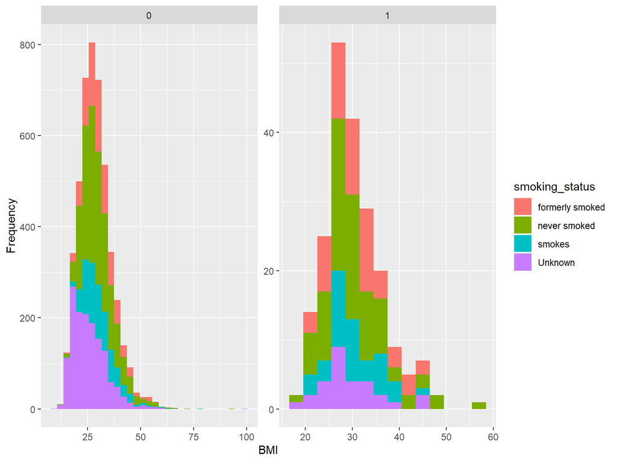

Histogram of BMI by stroke status overlapped by smoking status.

### Histogram of Average Glucose Levels

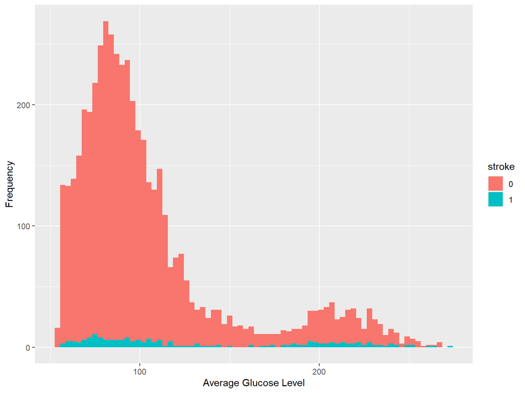

Histogram of average glucose level by stroke status where not much difference can be seen between the average glucose level by stroke status

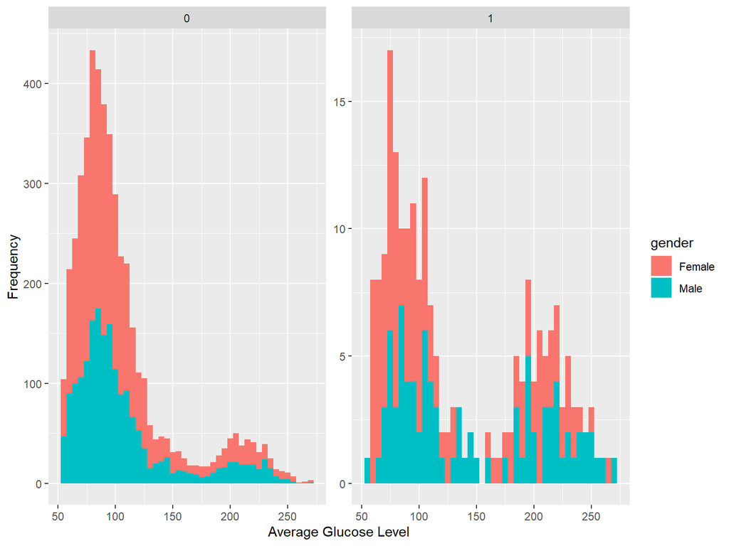

Histogram of average glucose level by stroke status overlapped by gender. Hard to get anything from this when the stroke=1 histogram looks more discrete, but not much difference.

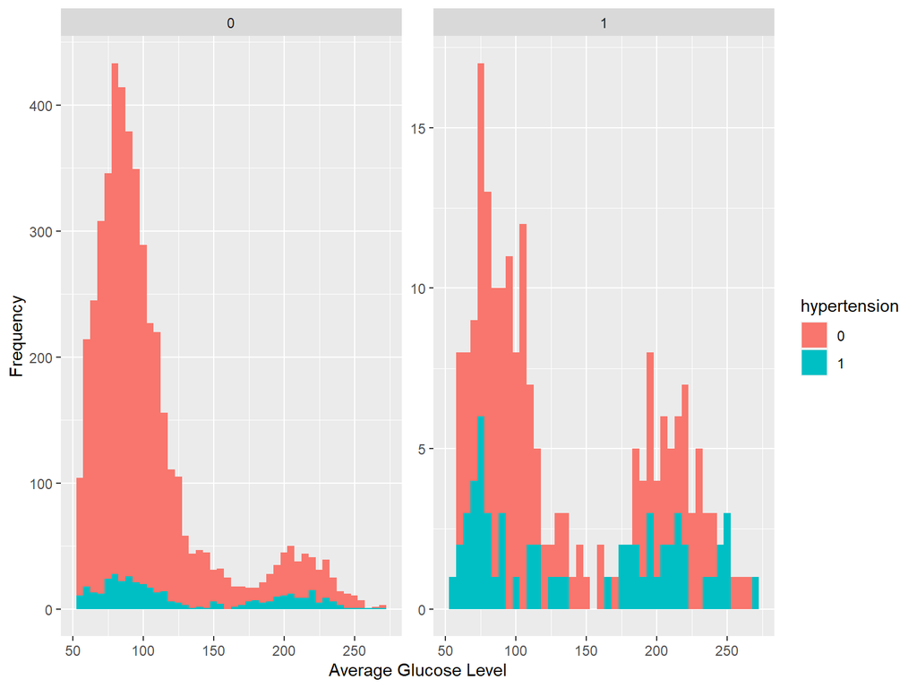

Histogram of average glucose level by stroke status overlapped by hypertension, but not much difference.

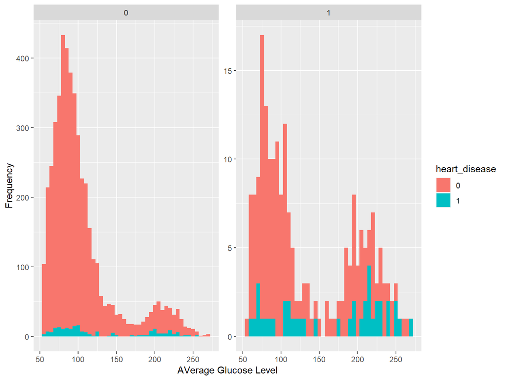

Histogram of average glucose level by stroke status overlapped by heart disease, but not seeing much difference.

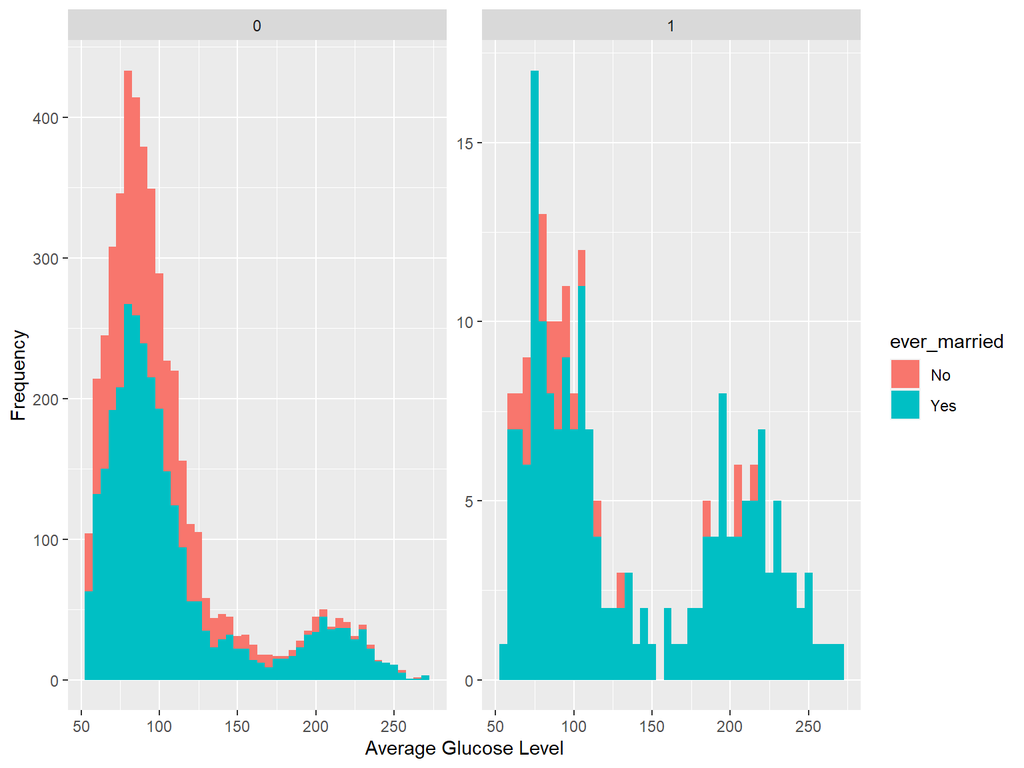

Histogram of average glucose level by stroke status overlapped by ever married, but not much difference seen.

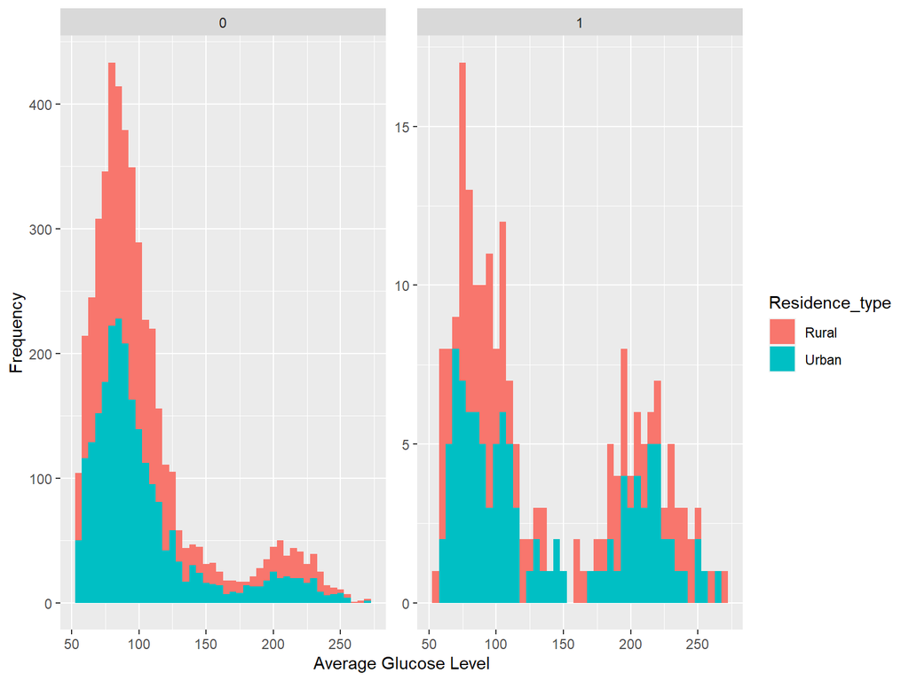

Histogram of average glucose level by stroke status overlapped by Residence type. Hard to see a difference here.

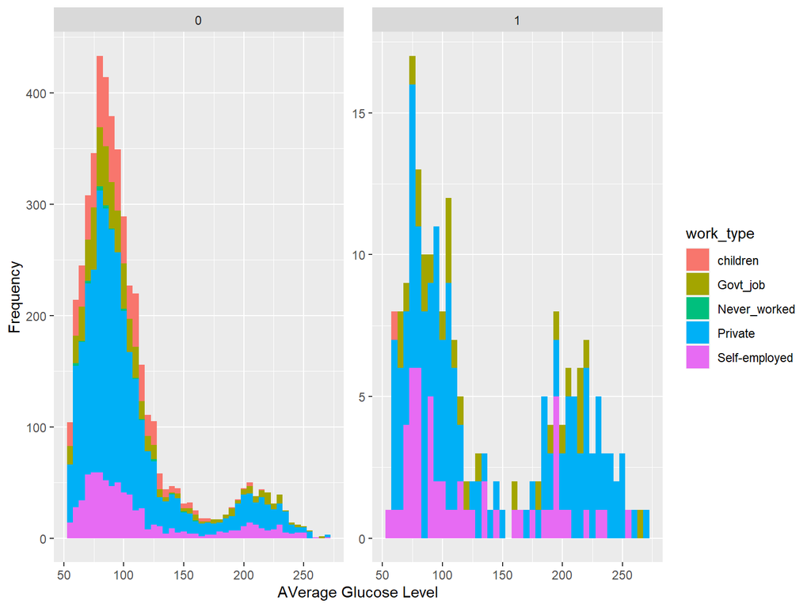

Histogram of average glucose level by stroke status overlapped by work type.

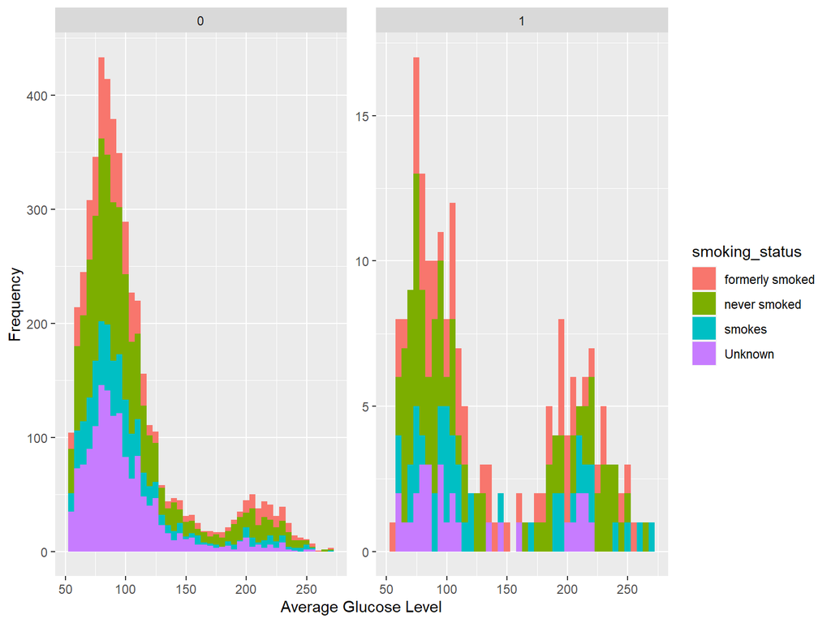

Histogram of average glucose level by stroke status overlapped by smoking status.

### Histogram of Age

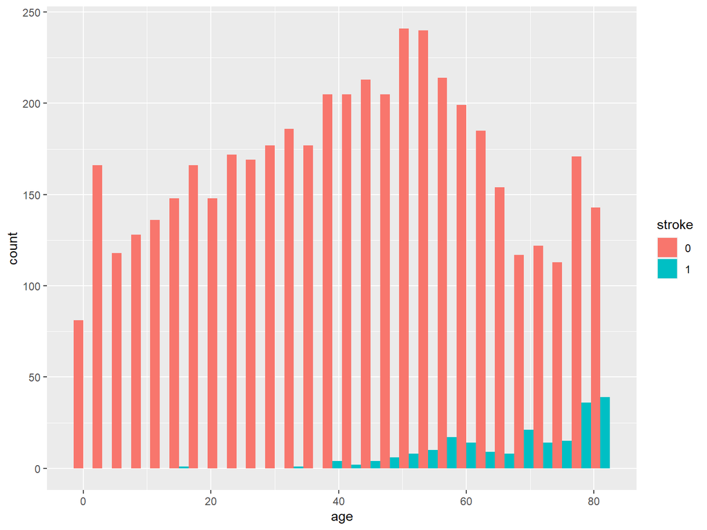

Skewed left histogram in terms of age for the stroke patients, seemingly indicating that the age of patients who encountered a stroke is higher than those who did not.

# Prediction Models

We decided that Generalized Linear Model and Random Forest are the best prediction models for our dataset.

# Analyzing General Linear Model (GLM) and Random Forest (RF)

Here we have a loop that computes misclassification rates and AUC scores for both GLM and RF 20 times, and each time using a different seed and training and test set.

When ntree=200, the AUC score for Random Forest is almost equivalent to the General Linear Model’s AUC score, which is about 0.5. Random Forest actually does a bit worse than General Linear Model. Even when I increase ntree to 400 and 1000, the AUC score for RF doesn’t increase.

# Summary Results Comparing Predictions of GLM and RF

This shows a table of misclassification rate and AUC score between GLM and RF as well as the summary of them.

```
##     Log_Error   RF_Error
## 1  0.04412763 0.04684318
## 2  0.04480652 0.04412763
## 3  0.03937542 0.04073320
## 4  0.04684318 0.04684318
## 5  0.04820095 0.04820095
## 6  0.03530210 0.03530210
## 7  0.04548540 0.04548540
## 8  0.03598099 0.03598099
## 9  0.04344874 0.04548540
## 10 0.04141208 0.04141208
## 11 0.04480652 0.04616429
## 12 0.04276986 0.04344874
## 13 0.04005431 0.04141208
## 14 0.03530210 0.03598099
## 15 0.04412763 0.04276986
## 16 0.03801765 0.03801765
## 17 0.04752206 0.04752206
## 18 0.04344874 0.04412763
## 19 0.04073320 0.04209097
## 20 0.04073320 0.04141208
```

```
##      Log_AUC    RF_AUC
## 1  0.5149254 0.4992888
## 2  0.5000000 0.5147961
## 3  0.5166667 0.5000000
## 4  0.5071429 0.5071429
## 5  0.5000000 0.5000000
## 6  0.5000000 0.5000000
## 7  0.5000000 0.5000000
## 8  0.5000000 0.5000000
## 9  0.5000000 0.4989354
## 10 0.5000000 0.5000000
## 11 0.4996449 0.4989347
## 12 0.5000000 0.4996454
## 13 0.5083333 0.4996461
## 14 0.5094340 0.5000000
## 15 0.4992908 0.5000000
## 16 0.5085757 0.5000000
## 17 0.5000000 0.5000000
## 18 0.5076923 0.5000000
## 19 0.5079795 0.4992923
## 20 0.5000000 0.4996461
```

```
##           vars  n mean sd median trimmed mad  min  max range  skew kurtosis se
## Log_Error    1 20 0.04  0   0.04    0.04   0 0.04 0.05  0.01 -0.33    -1.04  0
## RF_Error     2 20 0.04  0   0.04    0.04   0 0.04 0.05  0.01 -0.48    -0.98  0
```

```
##         vars  n mean   sd median trimmed mad min  max range skew kurtosis se
## Log_AUC    1 20  0.5 0.01    0.5     0.5   0 0.5 0.52  0.02 0.87    -0.62  0
## RF_AUC     2 20  0.5 0.00    0.5     0.5   0 0.5 0.51  0.02 2.90     7.60  0
```

Random forest and General Linear Model displayed similar misclassification rates; however, we noticed most of the data was stroke=0. Therefore, misclassification rate is not good for gauging the performance of each prediction model. AUC scores from ROC must be used to determine the performance of each model.

### Graphing AUC Scores of GLM and RF

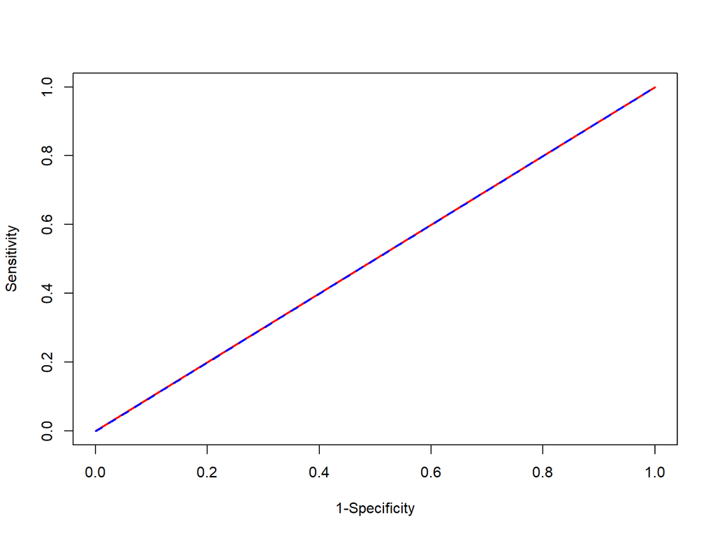

We see that both lines are basically equivelant to the chance line, which is not good!

# Variable Importance and Multicollinearity

Let’s look at the significant variables for each model and multicollinearity.

```
##
## Call:
## glm(formula = stroke ~ ., family = binomial(link = logit), data = train)
##
## Deviance Residuals:
##      Min        1Q    Median        3Q       Max
## -1.17436  -0.29002  -0.15629  -0.07102   3.15410
##
## Coefficients:
##                              Estimate Std. Error z value Pr(>|z|)
## (Intercept)                -2.021e+01  4.970e+02  -0.041 0.967564
## genderMale                 -8.688e-02  1.841e-01  -0.472 0.636945
## age                         6.921e-02  7.473e-03   9.261  < 2e-16 ***
## hypertension1               7.196e-01  2.030e-01   3.544 0.000394 ***
## heart_disease1              4.004e-01  2.502e-01   1.600 0.109513
## ever_marriedYes             1.463e-01  3.248e-01   0.451 0.652302
## work_typeGovt_job           1.227e+01  4.970e+02   0.025 0.980300
## work_typeNever_worked      -7.387e-01  2.572e+03   0.000 0.999771
## work_typePrivate            1.249e+01  4.970e+02   0.025 0.979953
## work_typeSelf-employed      1.218e+01  4.970e+02   0.025 0.980449
## Residence_typeUrban         6.932e-02  1.788e-01   0.388 0.698274
## avg_glucose_level           4.756e-03  1.542e-03   3.085 0.002038 **
## bmi                        -1.161e-03  1.434e-02  -0.081 0.935477
## smoking_statusnever smoked -5.210e-02  2.223e-01  -0.234 0.814650
## smoking_statussmokes        2.478e-01  2.762e-01   0.897 0.369617
## smoking_statusUnknown      -3.375e-01  2.985e-01  -1.131 0.258143
## ---
## Signif. codes:  0 '***' 0.001 '**' 0.01 '*' 0.05 '.' 0.1 ' ' 1
##
## (Dispersion parameter for binomial family taken to be 1)
##
##     Null deviance: 1226.51  on 3434  degrees of freedom
## Residual deviance:  953.34  on 3419  degrees of freedom
## AIC: 985.34
##
## Number of Fisher Scoring iterations: 18
```

```
##                       GVIF Df GVIF^(1/(2*Df))
## gender            1.038062  1        1.018853
## age               1.237665  1        1.112504
## hypertension      1.059567  1        1.029353
## heart_disease     1.090178  1        1.044116
## ever_married      1.023673  1        1.011767
## work_type         1.078646  4        1.009508
## Residence_type    1.009350  1        1.004664
## avg_glucose_level 1.107348  1        1.052306
## bmi               1.097994  1        1.047852
## smoking_status    1.092557  3        1.014863
```

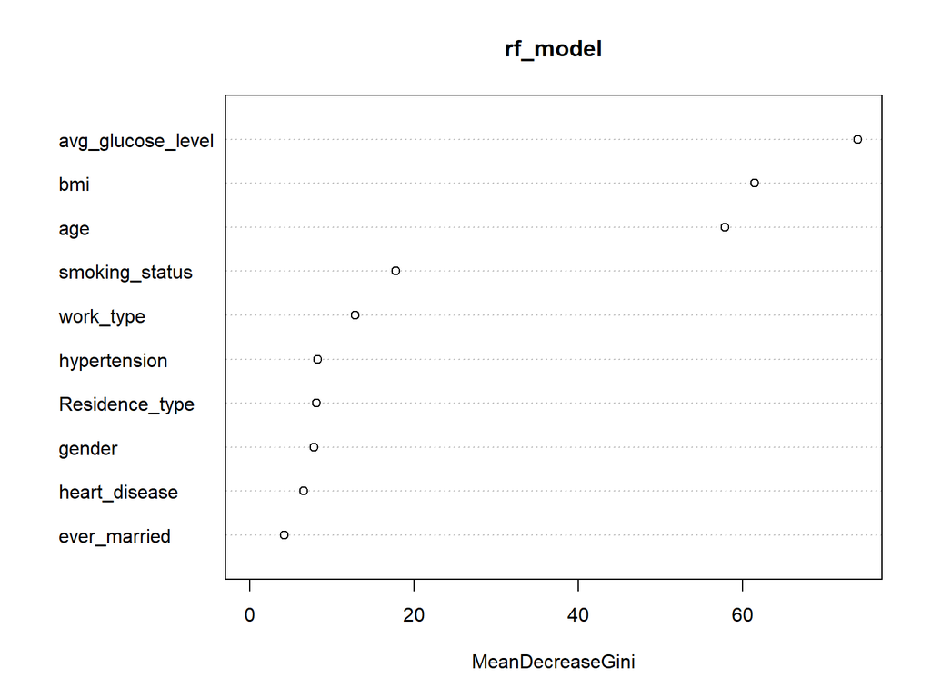

Average glucose level, BMI, and age have very high importance in the RF model, whereas, age, hypertension, and average glucose level are highly significant in the GLM model. There’s also no multicollinearity issues.

### Partial Dependency Plots

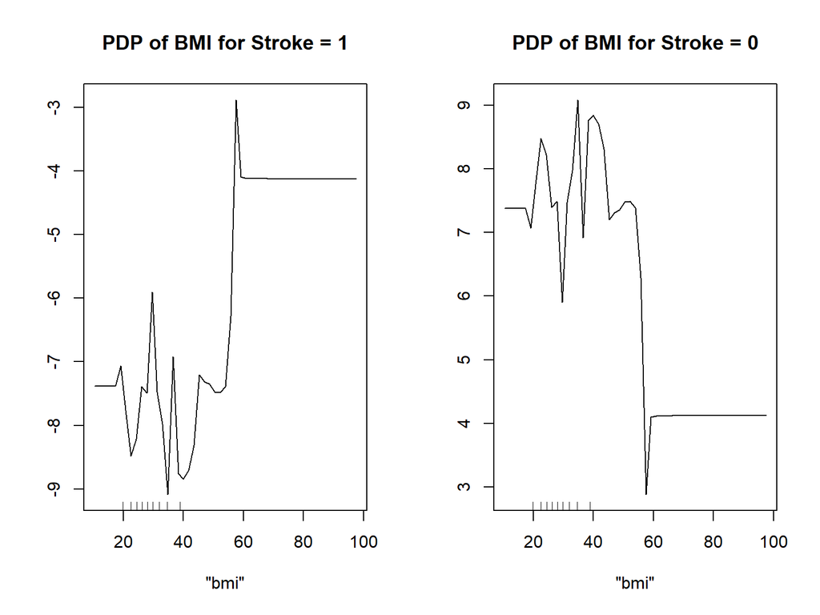

Partial Dependency Plot for BMI, the positive trend in stroke = 1 means that as BMI increases the model is more likely to predict the patient as a stroke patient.

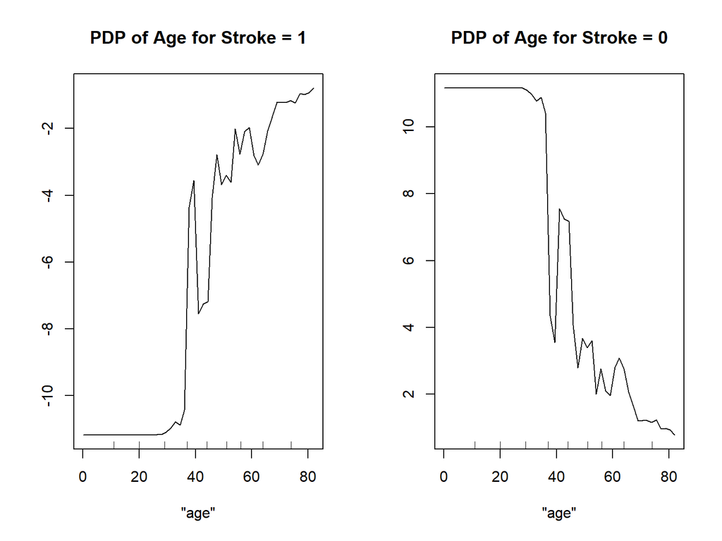

Partial Dependency Plot for age, the positive trend in stroke = 1 means that as age increases the model is more likely to predict the patient as a stroke patient.

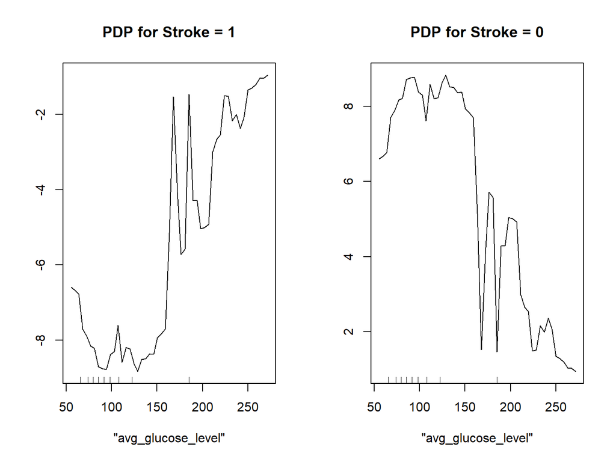

Partial Dependency Plot for average glucose level, the positive trend in stroke = 1 means that as average glucose level increases the model is more likely to predict the patient as a stroke patient.

### Density Plots

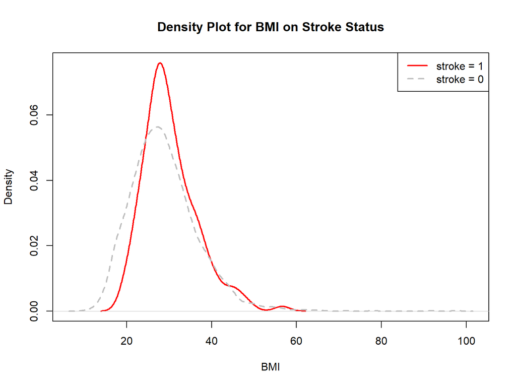

We can see that the BMI of stroke patients are a bit larger than non-stroke patients, but there’s no clear threshold.

[figure not shown]

[figure not shown]

# Looking into MatchIt

After seeing the discrepancy between the misclassification rate and AUC score of both General Linear Model and RF model, we noticed that our dataset is severely imbalanced. There were only 209 stroke patients out of 4,908 patients which is 4.26%. To address this issue, we tried the nearest neighbor matching method using the MatchIt package in R. - MatchIt is used to address issues when you have an unbalanced dataset by calculating propensity score (2). Propensity score is a method used to balance explanatory variables between treatment (stroke = 1) and control (stroke = 0) groups, reducing bias and enabling more valid causal inferences in observational studies. - Propensity scores are calculated using General Linear Model to estimate the probability of being assigned the treatment based on observed explanatory variables. These scores are used for matching or weighting to create balanced treatment and control groups.

- First, let’s look at the initial imbalance of the data prior to matching which is why method = NULL. We set distance = “glm” for generalized linear model, which implements General Linear Model by default.

```
##
## Call:
## matchit(formula = stroke ~ ., data = data, method = NULL, distance = "glm")
##
## Summary of Balance for All Data:
##                               Means Treated Means Control Std. Mean Diff.
## distance                             0.1377        0.0384          0.9596
## genderFemale                         0.5742        0.5910         -0.0340
## genderMale                           0.4258        0.4090          0.0340
## age                                 67.7129       41.7638          2.0922
## hypertension0                        0.7129        0.9168         -0.4506
## hypertension1                        0.2871        0.0832          0.4506
## heart_disease0                       0.8086        0.9568         -0.3767
## heart_disease1                       0.1914        0.0432          0.3767
## ever_marriedNo                       0.1100        0.3577         -0.7915
## ever_marriedYes                      0.8900        0.6423          0.7915
## work_typechildren                    0.0048        0.1426         -1.9969
## work_typeGovt_job                    0.1340        0.1281          0.0172
## work_typeNever_worked                0.0000        0.0047         -0.0701
## work_typePrivate                     0.6077        0.5710          0.0751
## work_typeSelf-employed               0.2536        0.1536          0.2297
## Residence_typeRural                  0.4785        0.4933         -0.0297
## Residence_typeUrban                  0.5215        0.5067          0.0297
## avg_glucose_level                  134.5714      103.9954          0.4895
## bmi                                 30.4713       28.8244          0.2602
## smoking_statusformerly smoked        0.2727        0.1658          0.2401
## smoking_statusnever smoked           0.4019        0.3763          0.0523
## smoking_statussmokes                 0.1866        0.1485          0.0977
## smoking_statusUnknown                0.1388        0.3094         -0.4937
##                               Var. Ratio eCDF Mean eCDF Max
## distance                          3.0748    0.3527   0.5549
## genderFemale                           .    0.0168   0.0168
## genderMale                             .    0.0168   0.0168
## age                               0.3102    0.2517   0.5304
## hypertension0                          .    0.2039   0.2039
## hypertension1                          .    0.2039   0.2039
## heart_disease0                         .    0.1482   0.1482
## heart_disease1                         .    0.1482   0.1482
## ever_marriedNo                         .    0.2477   0.2477
## ever_marriedYes                        .    0.2477   0.2477
## work_typechildren                      .    0.1378   0.1378
## work_typeGovt_job                      .    0.0059   0.0059
## work_typeNever_worked                  .    0.0047   0.0047
## work_typePrivate                       .    0.0367   0.0367
## work_typeSelf-employed                 .    0.0999   0.0999
## Residence_typeRural                    .    0.0148   0.0148
## Residence_typeUrban                    .    0.0148   0.0148
## avg_glucose_level                 2.1102    0.1290   0.2532
## bmi                               0.6405    0.0442   0.1697
## smoking_statusformerly smoked          .    0.1069   0.1069
## smoking_statusnever smoked             .    0.0257   0.0257
## smoking_statussmokes                   .    0.0381   0.0381
## smoking_statusUnknown                  .    0.1707   0.1707
##
## Sample Sizes:
##           Control Treated
## All          4699     209
## Matched      4699     209
## Unmatched       0       0
## Discarded       0       0
```

Values of standardized mean differences and eCDF statistics close to zero and values of variance ratios close to one indicate good balance, and here many of them are far from their ideal values.

### Nearest Neighbor Matching Method

Now, we begin by briefly demonstrating 1:1 nearest neighbor (NN) matching by the propensity score, which is appropriate for estimating the average treatment effect in the treated (ATT). One by one, each treated unit is paired with a control unit that has the closest propensity score to it. Any remaining control units are left unmatched and excluded from further analysis.

```
## A matchit object
##  - method: 1:1 nearest neighbor matching without replacement
##  - distance: Propensity score
##              - estimated with logistic regression
##  - number of obs.: 4908 (original), 418 (matched)
##  - target estimand: ATT
##  - covariates: gender, age, hypertension, heart_disease, ever_married, work_type, Residence_type, avg_glucose_level, bmi, smoking_status
```

```
##
## Call:
## matchit(formula = stroke ~ ., data = data, method = "nearest",
##     distance = "glm")
##
## Summary of Balance for Matched Data:
##                               Means Treated Means Control Std. Mean Diff.
## distance                             0.1377        0.1365          0.0111
## genderFemale                         0.5742        0.5407          0.0677
## genderMale                           0.4258        0.4593         -0.0677
## age                                 67.7129       67.6938          0.0015
## hypertension0                        0.7129        0.6890          0.0529
## hypertension1                        0.2871        0.3110         -0.0529
## heart_disease0                       0.8086        0.8660         -0.1460
## heart_disease1                       0.1914        0.1340          0.1460
## ever_marriedNo                       0.1100        0.0957          0.0459
## ever_marriedYes                      0.8900        0.9043         -0.0459
## work_typechildren                    0.0048        0.0000          0.0693
## work_typeGovt_job                    0.1340        0.1148          0.0562
## work_typeNever_worked                0.0000        0.0000          0.0000
## work_typePrivate                     0.6077        0.6268         -0.0392
## work_typeSelf-employed               0.2536        0.2584         -0.0110
## Residence_typeRural                  0.4785        0.4498          0.0575
## Residence_typeUrban                  0.5215        0.5502         -0.0575
## avg_glucose_level                  134.5714      136.8124         -0.0359
## bmi                                 30.4713       30.8187         -0.0549
## smoking_statusformerly smoked        0.2727        0.2823         -0.0215
## smoking_statusnever smoked           0.4019        0.4354         -0.0683
## smoking_statussmokes                 0.1866        0.1627          0.0614
## smoking_statusUnknown                0.1388        0.1196          0.0554
##                               Var. Ratio eCDF Mean eCDF Max Std. Pair Dist.
## distance                          1.0679    0.0003   0.0239          0.0143
## genderFemale                           .    0.0335   0.0335          0.9967
## genderMale                             .    0.0335   0.0335          0.9967
## age                               1.1035    0.0095   0.0670          0.4753
## hypertension0                          .    0.0239   0.0239          0.7932
## hypertension1                          .    0.0239   0.0239          0.7932
## heart_disease0                         .    0.0574   0.0574          0.6081
## heart_disease1                         .    0.0574   0.0574          0.6081
## ever_marriedNo                         .    0.0144   0.0144          0.5963
## ever_marriedYes                        .    0.0144   0.0144          0.5963
## work_typechildren                      .    0.0048   0.0048          0.0693
## work_typeGovt_job                      .    0.0191   0.0191          0.6462
## work_typeNever_worked                  .    0.0000   0.0000          0.0000
## work_typePrivate                       .    0.0191   0.0191          0.9211
## work_typeSelf-employed                 .    0.0048   0.0048          0.8688
## Residence_typeRural                    .    0.0287   0.0287          1.1685
## Residence_typeUrban                    .    0.0287   0.0287          1.1685
## avg_glucose_level                 0.9502    0.0164   0.0670          0.9260
## bmi                               0.8899    0.0131   0.0670          1.0633
## smoking_statusformerly smoked          .    0.0096   0.0096          0.7950
## smoking_statusnever smoked             .    0.0335   0.0335          0.9076
## smoking_statussmokes                   .    0.0239   0.0239          0.7246
## smoking_statusUnknown                  .    0.0191   0.0191          0.4983
##
## Sample Sizes:
##           Control Treated
## All          4699     209
## Matched       209     209
## Unmatched    4490       0
## Discarded       0       0
```

### Visualizing the Propensity Score

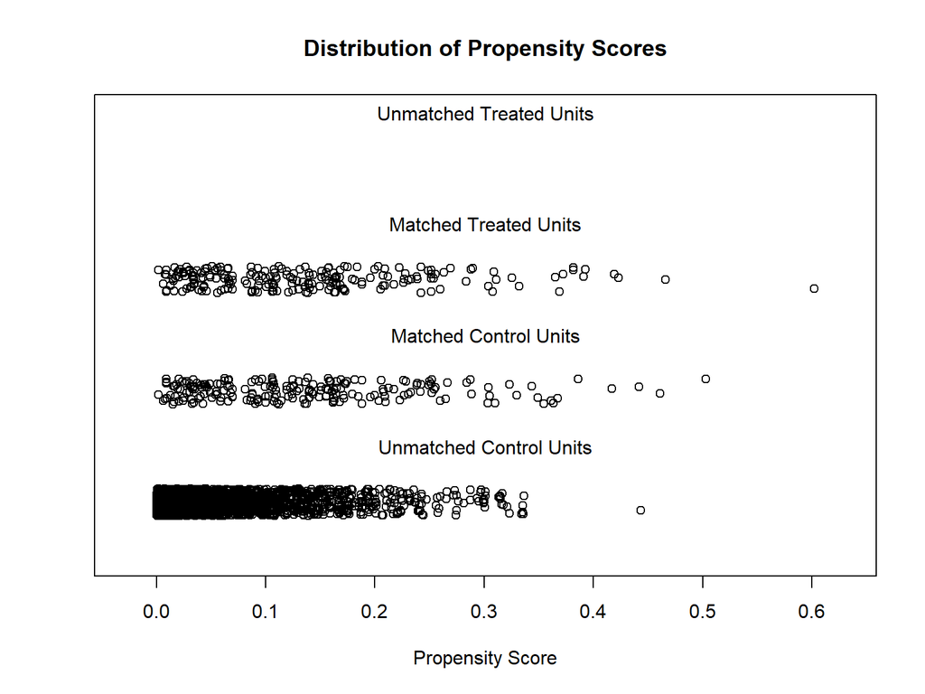

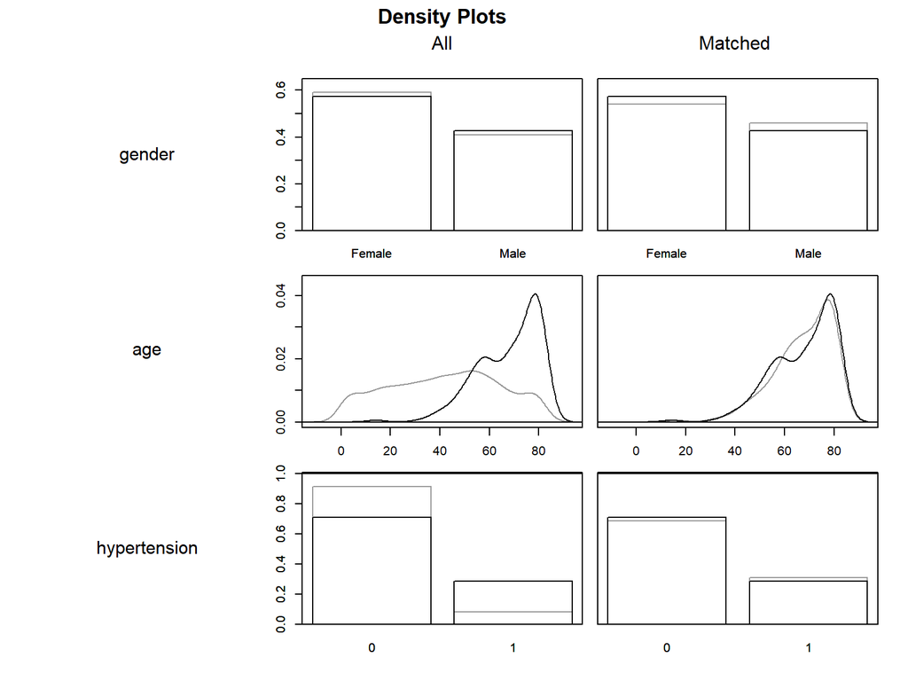

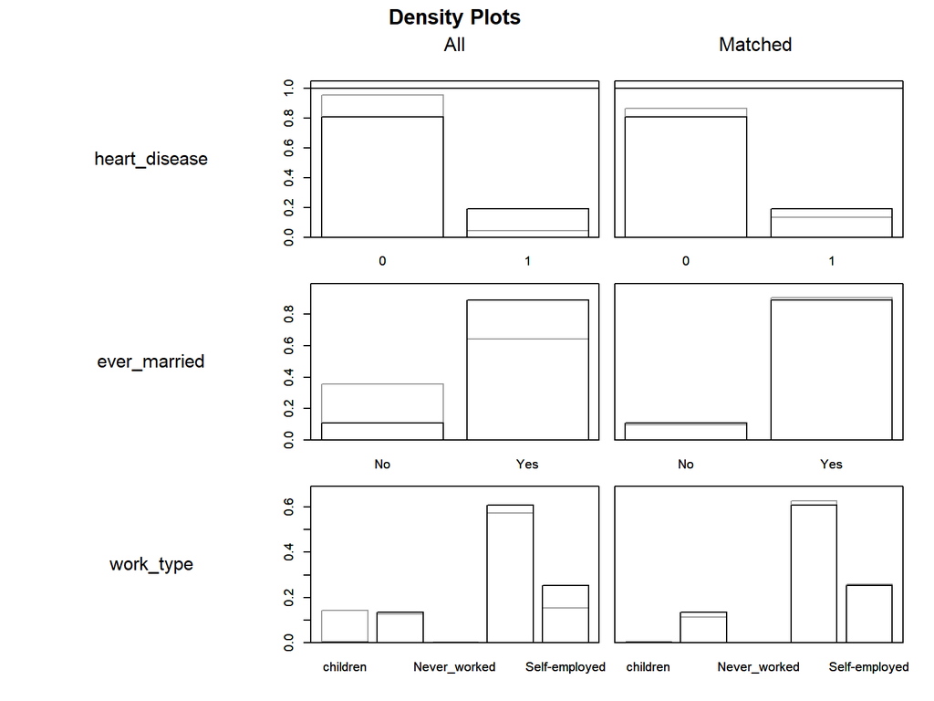

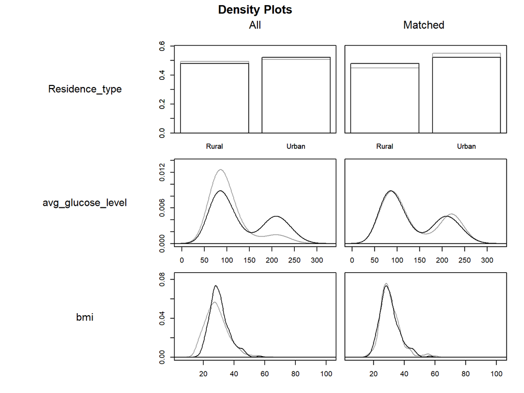

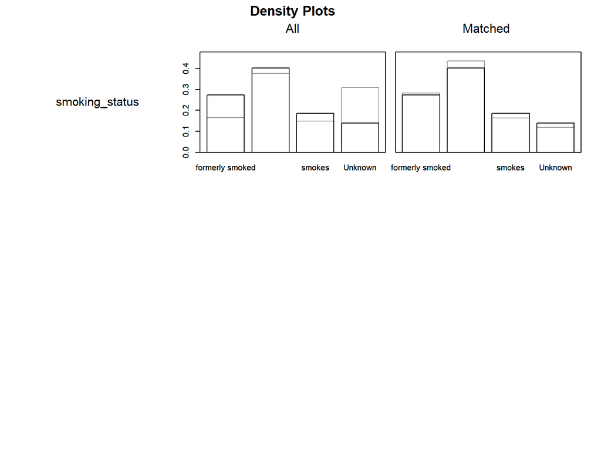

Based these plots, I believe nearest neighbor propensity score matching is sufficient in balancing the data.

# Modeling with the Matched Data

Because matching adds three extra columns (weights, distance, subclass) to the data when computing propensity score, those columns were removed in the regression and prediction analysis.

# Summary Results Comparing Predictions of GLM and RF After Matching

```
##   Log_Error  RF_Error
## 1 0.5555556 0.5555556
## 2 0.5396825 0.5396825
## 3 0.5079365 0.5396825
```

```
##     Log_AUC    RF_AUC
## 1 0.4561404 0.4469870
## 2 0.4598485 0.4560606
## 3 0.4920635 0.4603175
```

```
##           vars n mean   sd median trimmed  mad  min  max range  skew kurtosis
## Log_Error    1 3 0.53 0.02   0.54    0.53 0.02 0.51 0.56  0.05 -0.21    -2.33
## RF_Error     2 3 0.54 0.01   0.54    0.54 0.00 0.54 0.56  0.02  0.38    -2.33
##             se
## Log_Error 0.01
## RF_Error  0.01
```

```
##         vars n mean   sd median trimmed  mad  min  max range  skew kurtosis
## Log_AUC    1 3 0.47 0.02   0.46    0.47 0.01 0.46 0.49  0.04  0.37    -2.33
## RF_AUC     2 3 0.45 0.01   0.46    0.45 0.01 0.45 0.46  0.01 -0.22    -2.33
##           se
## Log_AUC 0.01
## RF_AUC  0.00
```

Nearest neighbor method matched 418 observations. General Linear Model and RF was performed on the matched data. General Linear Model showed that none of the explanatory variables were significant aside from age. General Linear Model performance were misclassification score = 0.5343915 and AUC score = 0.4693508. RF performance were misclassification score = 0.5449735 and AUC score = 0.454455. Both models performed very poorly.

# Analyzing Based on Prevalence

In the United States, each year 795,000 suffer from a stroke (3). If we divide that number by the US population, there is about a 0.24% chance of US citizens getting a stroke per year (4). The test set contains 1473 observations. If we multiply the number of rows by the prevalence, it will give us the number of stroke GLM and RF should predict the test set to have which is about 3-4 stroke patients.

```
## [1] "The highest probability of stroke patient using GLM is 0.470151588426705 and 0.464154984704355 and 0.431068270907549 and 0.417094558375049"
```

```
## [1] "The highest probability of stroke patient using RF is 0.56 and 0.493333333333333 and 0.486666666666667 and 0.453333333333333"
```

```
## [1] "The number of predicted stroke using RF vs prevalence of stroke in test set is 1 vs 4"
```

```
## [1] "The number of predicted stroke using GLM vs prevalence of stroke in test set is 0 vs 4"
```

RF predicted 1 stroke patient and GLM predicted none when hypothetically there should have been 3-4, which is not a sign of good model accuracy and performance.

# Model Performance Based on Variable Reduction for GLM

Using stepAIC to create the reduced model, the reduced model was analyzed based on prediction performance.

```
## Start:  AIC=985.34
## stroke ~ gender + age + hypertension + heart_disease + ever_married +
##     work_type + Residence_type + avg_glucose_level + bmi + smoking_status
##
##                     Df Deviance     AIC
## - work_type          4   956.52  980.52
## - smoking_status     3   956.71  982.71
## - bmi                1   953.35  983.35
## - Residence_type     1   953.49  983.49
## - ever_married       1   953.55  983.55
## - gender             1   953.56  983.56
## <none>                   953.34  985.34
## - heart_disease      1   955.79  985.79
## - avg_glucose_level  1   962.58  992.58
## - hypertension       1   965.14  995.14
## - age                1  1056.50 1086.50
##
## Step:  AIC=980.52
## stroke ~ gender + age + hypertension + heart_disease + ever_married +
##     Residence_type + avg_glucose_level + bmi + smoking_status
##
##                     Df Deviance     AIC
## - smoking_status     3   960.11  978.11
## - bmi                1   956.52  978.52
## - Residence_type     1   956.64  978.64
## - gender             1   956.74  978.74
## - ever_married       1   956.92  978.92
## <none>                   956.52  980.52
## - heart_disease      1   959.29  981.29
## + work_type          4   953.34  985.34
## - avg_glucose_level  1   965.73  987.73
## - hypertension       1   968.14  990.14
## - age                1  1068.00 1090.00
##
## Step:  AIC=978.11
## stroke ~ gender + age + hypertension + heart_disease + ever_married +
##     Residence_type + avg_glucose_level + bmi
##
##                     Df Deviance     AIC
## - bmi                1   960.12  976.12
```

[output cut: 62 more lines]

```
## Step:  AIC=970.94
## stroke ~ age + hypertension + heart_disease + avg_glucose_level
##
##                     Df Deviance     AIC
## <none>                   960.94  970.94
## - heart_disease      1   963.95  971.95
## + ever_married       1   960.46  972.46
## + gender             1   960.75  972.75
## + Residence_type     1   960.82  972.82
## + bmi                1   960.94  972.94
## + smoking_status     3   957.25  973.25
## + work_type          4   957.32  975.32
## - avg_glucose_level  1   970.86  978.86
## - hypertension       1   974.03  982.03
## - age                1  1107.06 1115.06
```

```
## [1] 2
```

Because the reduced GLM model predicted 2 stroke patients and the AUC score is 0.4992923, the reduced GLM doesn’t really perform better than the full model.

# Conclusion

Random Forest and General Linear Model are two of the more common and favorable models when dealing with binary classification predictions. In this analysis, we saw how poorly both of them performed on this dataset. This makes us believe that because the prevalence of having a stroke is so rare, a much larger dataset other/more explanatory variables must be used in order for RF or GLM to spot the tiniest differences between stroke patients and non-stroke patients. When using larger or more complex datasets, RF is probably the better option. However, on small to moderately sized dataset, GLM is easier to interpret and likely to perform just as well.

# References

1. Fedesoriano. “Stroke Prediction Dataset.” Kaggle, 26 Jan. 2021, www.kaggle.com/datasets/fedesoriano/stroke-prediction-dataset/data.
2. Greifer, Noah. Matchit: Getting Started, 12 Oct. 2023, cran.r-project.org/web/packages/MatchIt/vignettes/MatchIt.html.
3. Jose Vega MD, PhD. “Interesting and Surprising Facts and Statistics about Stroke.” Verywell Health, Verywell Health, 6 Apr. 2022, www.verywellhealth.com/facts-and-statistics-about-stroke-3146382.
4. “U.S. Population 1950-2023.” MacroTrends, www.macrotrends.net/countries/USA/united-states/population#:~:text=The%20current%20population%20of%20U.S.%20in%202021%20is,2019%20was%20329%2C064%2C917%2C%20a%200.6%25%20increase%20from%202018. Accessed 22 Oct. 2023.